# GH 536 Homework 3

Chris Troeger

2/17/2022

# Background to Question 1.

Consider the MEMA kwa Vijana adolescent sexual health intervention in Tanzania. 20 rural communities were grouped into three strata expected to have high, medium, or low risk of HIV and other STIs. Half the communities in each stratum were assigned to receive the intervention versus standard education. The trial captured individual-level responses on knowledge, attitudes, sexual behavior, HIV incidence, STI incidence, and pregnancy. The data needed for this assignment is mkvtrial.tab and contains data collected from male participants at follow-up and focuses on knowledge regarding HIV acquisition. For this dataset,

- community – community number: 1-20
- arm – treatment arm: 0=control, 1=intervention
- stratum – stratum level:1-3
- ethnicgp – 0=non-sukuma, 1=sumuma
- lifepart – lifetime partners at baseline: 0=0, 1=1, 2=2, 3=3+
- agegp – age-group at follow-up: 1=16-17, 2=18, 3=19+
- know – good knowledge of HIV acquisition at follow-up: 0=no, 1=yes
- id – individual number

The authors report a RR of 1.44 (95% CI of 1.25, 1.67) for the impact of intervention on knowledge of HIV acquisition for young men (Table 3).

1. **Conduct an individual-level analysis using a mixed effects regression model accounting for both community and stratum, and compare your results (and approach) to that presented in the publication.**
2. **Further, investigate whether the number of lifetime partners at baseline results in a different effect estimate for the intervention by including an interaction term for this variable.**

Feel free to include or ignore the other covariates.

### Part 1

There are several models one could use to evaluate the relative risk of good knowledge of HIV acquisition in the treatment compared to control arms of this study but I expect most of them would have this general structure:

$$y_i = \beta_0 + \alpha_{0j,i} + \beta_1Stratum_i + \beta_2Arm_i + \epsilon_i$$

Where $y_i$ is the knowledge of HIV acquisition for individual $i$, $\beta_0$ is the intercept term, $\beta_1$ is a fixed effect for stratum, $\beta_2$ is the primary effect of interest, whether individual $i$ is in the treatment or control arm, $\epsilon_i$ is the error term, and $\alpha_{0j,i}$ is a random intercept term for community $j$.

We know our outcome variable is binary {0,1} so either a logistic regression model or a log-binomial model would be appropriate to analyze the data.

Here I show both.

```r
## I ran a log-binomial model
# This model returns beta estimates in log-relative risk
# stratum is categorical
mod1_lb <- glmer(know ~ arm + factor(stratum) + (1|community), data = dt,
              family = binomial(link = "log"))
sum_mod1 <- format_results(mod1_lb)

## One could also run a logistic regression model
# This model returns beta estimates in log-odds
mod1_lg <- glmer(know ~ arm + factor(stratum) + (1|community), data = dt,
              family = binomial)
sum_mod1_lg <- format_results(mod1_lg)
```

Fixed effect relative risk parameter estimates

| Parameter | Estimate | Lower bound | Upper bound |
| --- | --- | --- | --- |
| Intercept | 0.44 | 0.38 | 0.51 |
| Intervention arm | 1.46 | 1.27 | 1.68 |
| Stratum2 | 0.99 | 0.84 | 1.18 |
| Stratum3 | 1.02 | 0.85 | 1.22 |

Fixed effect odds ratio parameter estimates

| Parameter | Estimate | Lower bound | Upper bound |
| --- | --- | --- | --- |
| Intercept | 0.80 | 0.57 | 1.12 |
| Intervention arm | 2.39 | 1.72 | 3.30 |
| Stratum2 | 0.98 | 0.66 | 1.45 |
| Stratum3 | 1.09 | 0.71 | 1.66 |

This approach is different from the one used in the manuscript. In the manuscript, the analysis is a logistic regression model for all individuals but not accounting for the study arm.

$$y_i = \beta_0 + \beta_1Stratum_i + ... \epsilon_i$$

Where $...$ represents “predefined adjustment factors”. The Authors then used this model to estimate an *expected* knowledge of HIV acquisition count by community and then determined a relative risk from dividing the *observed* knowledge score by this expected value. They estimated uncertainty from these ratios using ANOVA tests.

```r
## Analysis from paper
# Run individual level analysis, not accounting for arm
paper_mod <- glm(know ~ factor(stratum) + ethnicgp + factor(agegp),
                 data = dt, family = binomial(link = "log"))
# Predict onto individuals the probability that know == 1
dt$paper_pred <- exp(predict(paper_mod))
# Aggregate observed and predicted (expected) to community, stratum, arm
tab_dt <- dt[, lapply(.SD, function(x) sum(x)),
             .SDcols = c("know","paper_pred"),
             by = c("community", "arm","stratum")]
# Find ratio
tab_dt[, o_e := know / paper_pred]
# The found "geometric" mean (this is the mean of the log-transformed datat)
tab_dt[, log_o_e := log(o_e)]

# The relative risk is the exponents of the means of arm == 1 to arm == 0
exp(mean(tab_dt[arm == 1]$log_o_e)) / exp(mean(tab_dt[arm == 0]$log_o_e))
```

```
## [1] 1.443932
```

The authors said they ran an ANOVA to get the standard errors. How would we do that?

```r
summary(aov(log_o_e ~ arm + stratum, data = tab_dt))
```

```
##             Df Sum Sq Mean Sq F value   Pr(>F)
## arm          1 0.6748  0.6748  30.095 4.02e-05 ***
## stratum      1 0.0002  0.0002   0.008     0.93
## Residuals   17 0.3812  0.0224
## ---
## Signif. codes:  0 '***' 0.001 '**' 0.01 '*' 0.05 '.' 0.1 ' ' 1
```

That’s nice but not how I like interpreting results. Fortunately for us, a one-way ANOVA is the same as a linear model for categorical variables!

```r
lin_mod <- lm(log_o_e ~ arm + factor(stratum), data = tab_dt)
summary(lin_mod)
```

```
##
## Call:
## lm(formula = log_o_e ~ arm + factor(stratum), data = tab_dt)
##
## Residuals:
##      Min       1Q   Median       3Q      Max
## -0.21120 -0.11203 -0.00403  0.04491  0.36969
##
## Coefficients:
##                   Estimate Std. Error t value Pr(>|t|)
## (Intercept)      -0.209351   0.071834  -2.914   0.0101 *
## arm               0.367370   0.069015   5.323 6.86e-05 ***
## factor(stratum)2  0.001372   0.083344   0.016   0.9871
## factor(stratum)3 -0.007714   0.089099  -0.087   0.9321
## ---
## Signif. codes:  0 '***' 0.001 '**' 0.01 '*' 0.05 '.' 0.1 ' ' 1
##
## Residual standard error: 0.1543 on 16 degrees of freedom
## Multiple R-squared:  0.6392, Adjusted R-squared:  0.5716
## F-statistic: 9.449 on 3 and 16 DF,  p-value: 0.0007897
```

```r
kable(format_results(lin_mod))
```

| beta | mean | lower | upper |
| --- | --- | --- | --- |
| (Intercept) | 0.8111107 | 0.7045881 | 0.9337378 |
| arm | 1.4439317 | 1.2612483 | 1.6530756 |
| factor(stratum)2 | 1.0013725 | 0.8504584 | 1.1790664 |
| factor(stratum)3 | 0.9923157 | 0.8333147 | 1.1816551 |

Compare that with the values reported in the paper…

Reported risk ratio estimate of knowledge of HIV acquisition in intervention to control arm

| Study estimate | Lower bound | Upper bound |
| --- | --- | --- |
| 1.44 | 1.25 | 1.67 |

### Part 2

The question also asks for an investigation of lifetime sexual partners at baseline as an interaction term with arm.

I can think of several possible models (log-binomial and logistic) and two ways to think about the `lifepart` variable.

What do we know about this new variable? We know that this variable is continuous 0, 1, 2 but at 3, it becomes 3 *or more*. Do we think that the probability of good knowledge should be linearly associated with partners?

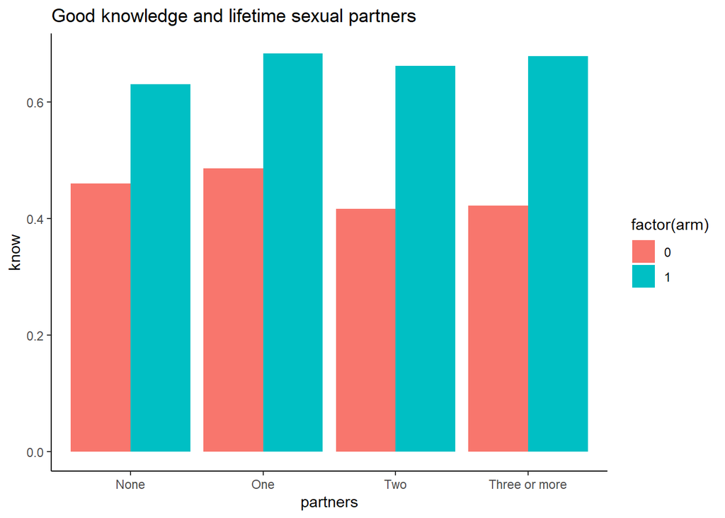

```r
## Refactor lifepart as we don't know that there is a linear change with partners?
dt[, partners := factor(lifepart, levels = c(0, 1, 2, 3),
                        labels = c("None","One","Two","Three or more"))]

partners_dt <- dt[, lapply(.SD, function(x) mean(x)),
                  .SDcols = "know",
                  by= c("arm","partners")]
ggplot(partners_dt, aes(x = partners, y = know, fill = factor(arm))) +
  theme_classic() +
  geom_bar(stat = "identity", position = position_dodge(width = 0.9)) +
  ggtitle("Good knowledge and lifetime sexual partners")
```

```r
mod2 <- glmer(know ~ arm*partners + factor(stratum) + (1|community), data = dt,
              family = binomial(link = "logit"))
```

Fixed Effects

| Parameter | Odds Ratio | SE | 95% CI | z | p |
| --- | --- | --- | --- | --- | --- |
| (Intercept) | 0.85 | 0.15 | (0.60, 1.21) | -0.92 | 0.359 |
| arm | 2.06 | 0.37 | (1.45, 2.93) | 4.06 | < .001 |
| partners (One) | 1.08 | 0.15 | (0.83, 1.42) | 0.57 | 0.567 |
| partners (Two) | 0.85 | 0.13 | (0.64, 1.14) | -1.09 | 0.276 |
| partners (Three or more) | 0.84 | 0.09 | (0.68, 1.05) | -1.52 | 0.129 |
| stratum (2) | 0.97 | 0.19 | (0.66, 1.44) | -0.14 | 0.888 |
| stratum (3) | 1.08 | 0.23 | (0.71, 1.65) | 0.38 | 0.707 |
| arm * partners (One) | 1.23 | 0.25 | (0.83, 1.81) | 1.02 | 0.309 |
| arm * partners (Two) | 1.33 | 0.29 | (0.87, 2.03) | 1.31 | 0.192 |
| arm * partners (Three or more) | 1.41 | 0.23 | (1.03, 1.94) | 2.12 | 0.034 |

Random Effects

| Parameter | Coefficient |
| --- | --- |
| SD (Intercept: community) | 0.34 |
| SD (Residual) | 1.00 |

We could also run this model with `lifepart` as a continuous variable.

```r
mod2b <- glmer(know ~ arm*lifepart + factor(stratum) + (1|community), data = dt,
              family = binomial(link = "logit"))
```

Fixed Effects

| Parameter | Odds Ratio | SE | 95% CI | z | p |
| --- | --- | --- | --- | --- | --- |
| (Intercept) | 0.87 | 0.15 | (0.61, 1.23) | -0.80 | 0.422 |
| arm | 2.09 | 0.37 | (1.48, 2.94) | 4.20 | < .001 |
| lifepart | 0.94 | 0.03 | (0.88, 1.01) | -1.70 | 0.088 |
| stratum (2) | 0.97 | 0.19 | (0.66, 1.43) | -0.15 | 0.882 |
| stratum (3) | 1.08 | 0.23 | (0.71, 1.64) | 0.35 | 0.726 |
| arm * lifepart | 1.13 | 0.06 | (1.02, 1.25) | 2.27 | 0.023 |

Random Effects

| Parameter | Coefficient |
| --- | --- |
| SD (Intercept: community) | 0.34 |
| SD (Residual) | 1.00 |

Although I don’t think that `lifepart` should be continuous, it does make it easier to think about our interaction terms and what they mean. Let’s investigate from a prediction.

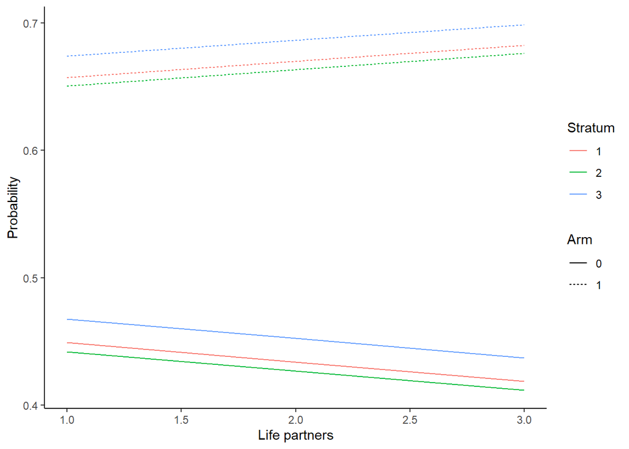

```r
lpred <- expand.grid(arm = 0:1,
                     stratum = 1:3,
                     lifepart = 1:3,
                     community = 21)
lpred$pred <- predict(mod2b, newdata = lpred,
                 allow.new.levels = T) # This is required for predicting a random intercept that isn't in the model. Why do I want to do this?

# The model is logistic regression so I want to inv.logit() to get the probability of good knowledge
lpred$pred <- inv.logit(lpred$pred)

ggplot(lpred, aes(x = lifepart, y = pred, lty = factor(arm), col = factor(stratum))) +
  geom_line() +
  scale_color_discrete("Stratum") +
  scale_linetype("Arm") +
  theme_classic() +
  xlab("Life partners") + ylab("Probability")
```

Maybe we want to use the log link again but this model doesn’t run. Can we figure out why?

```r
# mod2c <- glmer(know ~ arm*partners + factor(stratum) + (1|community), data = dt,
#               family = binomial(link = "log"))
```

This question thread seems to have an answer for us: https://stat.ethz.ch/pipermail/r-sig-mixed-models/2016q1/024453.html

I believe it has to do with communities that don’t have one of the level of arm*lifepart interaction.

```r
dt$arm_partner <- paste0(dt$arm, "_", dt$partners)
table(dt[community <= 10]$community, dt[community <= 10]$arm_partner)
```

```
##
##      0_None 0_One 0_Three or more 0_Two 1_None 1_One 1_Three or more 1_Two
##   1      93    31              74    28      0     0               0     0
##   2       0     0               0     0     69    34              41    25
##   3       0     0               0     0     90    37              61    31
##   4      86    25              46    18      0     0               0     0
##   5       0     0               0     0     89    27              66    22
##   6      66    43              57    28      0     0               0     0
##   7       0     0               0     0    101    32              52    22
##   8       0     0               0     0    132    23              52    30
##   9       0     0               0     0    134    24              50    11
##   10     80    17              61    28      0     0               0     0
```

This last log-binomial version does, however, because it considers `lifepart` as a continuous variable (I think this is a poor assumption though).

```r
mod2d <- glmer(know ~ arm*lifepart + factor(stratum) + (1|community), data = dt,
              family = binomial(link = "log"))
```

Fixed Effects

| Parameter | Risk Ratio | SE | 95% CI | z | p |
| --- | --- | --- | --- | --- | --- |
| (Intercept) | 0.46 | 0.04 | (0.40, 0.54) | -9.82 | < .001 |
| arm | 1.38 | 0.10 | (1.19, 1.60) | 4.24 | < .001 |
| lifepart | 0.97 | 0.02 | (0.93, 1.01) | -1.65 | 0.099 |
| stratum (2) | 0.99 | 0.09 | (0.84, 1.17) | -0.11 | 0.912 |
| stratum (3) | 1.02 | 0.09 | (0.85, 1.22) | 0.19 | 0.846 |
| arm * lifepart | 1.05 | 0.02 | (1.01, 1.10) | 2.21 | 0.027 |

Random Effects

| Parameter | Coefficient |
| --- | --- |
| SD (Intercept: community) | 0.15 |
| SD (Residual) | 1.00 |

# Background to Question 2.

Consider the ZAMSTAR data (zamstar.tab). The authors of the study recommended looking at interactions between strata & country, the community intervention and country, and the household intervention and country. If we consider country to be a second stratification, we may want to look into three way interactions between country, strata, and the intervention of interest. Conduct a cluster-level analysis looking at the impact of the household intervention, but account for the potential for a three-way interaction between country, strata, and the intervention.

- cid^ cluster ID: 1-25
- country^ 1=Zambia, 2=South Africa
- strata_tst^ 0=Low TST stratum, 1=High TST stratum
- ecf^ enhanced case-finding intervention: 0=No, 1=Yes
- hh^ household intervention: 0=No, 1=Yes
- d^ number of prevalent TB cases
- n^ number with evaluable sample

## Response

The model I expect to see looks like this:

`glm(d ~ offset(log(n)) + country*strata_tst*hh, data = zt, family = poisson)`

That is equivalent to:

$$y_j = \beta_0 + \beta_1HH_j + \beta_2Country_j + \beta_3Stratum_j + \beta_4Country_jStratum_j +$$
$$\beta_5Country_jHH_j + \beta_6Stratum_jHH_j + \beta_7Country_jStratum_jHH_j + \epsilon_j$$

Where $y_j$ is the incidence ($\frac{d}{n}$) for cluster $j$, $HH_j$ is if the household intervention occurred in cluster $j$, $\epsilon_j$ is the error term, and $Country_j$ & $Stratum_j$ are the country and stratum for cluster $j$.

The table below shows the relative risk estimates from this regression model. These results suggest no significant impact of household treatment on the outcome.

Relative risk parameter estimates from ZAMSTAR cluster level analysis

| Parameter | Estimate | Lower bound | Upper bound |
| --- | --- | --- | --- |
| Intercept | 0.00 | 0.00 | 0.00 |
| Country | 4.36 | 3.10 | 6.11 |
| Stratum | 0.98 | 0.40 | 2.35 |
| Household TB-HIV care | 1.14 | 0.48 | 2.69 |
| Country-stratum interaction | 1.14 | 0.71 | 1.82 |
| Country-Household TB-HIV care interaction | 0.94 | 0.59 | 1.50 |
| Stratum-Household TB-HIV care interaction | 1.45 | 0.44 | 4.72 |
| Country-Household TB-HIV care-Stratum interaction | 0.78 | 0.41 | 1.48 |

### Let’s make some predictions to see how to interpret interaction terms

I am creating a dataframe for the prediction levels and importing a CSV I prepared that is the matrix of coefficients for the model. The idea is something like this.

```r
# Manually created file of a matrix of coefficients from the model
coef_mat <- fread("C:/Users/ctroeger/OneDrive - UW/PhD/GH Teaching Assistant/Data/zamstar_mod_coefs.csv")
names(coef_mat) <- paste0("c_", names(coef_mat))

pred_zt <- cbind(pred_zt, coef_mat)

pred_zt
```

```
##   country strata_tst hh    n                               name c_intercept
## 1       1          0  0 1000 Country1, Strata0, hh0 (Intercept)        -6.8
## 2       2          0  0 1000             Country2, Strata0, hh0        -6.8
## 3       1          1  0 1000             Country1, Strata1, hh0        -6.8
## 4       2          1  0 1000             Country2, Strata1, hh0        -6.8
## 5       1          0  1 1000             Country1, Strata0, hh0        -6.8
## 6       2          0  1 1000             Country2, Strata0, hh1        -6.8
## 7       1          1  1 1000             Country1, Strata1, hh1        -6.8
## 8       2          1  1 1000             Country2, Strata1, hh1        -6.8
##   c_country c_strata_tst c_hh c_country:strat_tst c_country:hh c_strata_tst:hh
## 1      0.00         0.00 0.00               0.000         0.00            0.00
## 2      1.47         0.00 0.00               0.000         0.00            0.00
## 3      0.00        -0.03 0.00               0.000         0.00            0.00
## 4      1.47        -0.03 0.00               0.127         0.00            0.00
## 5      0.00         0.00 0.13               0.000         0.00            0.00
## 6      1.47         0.00 0.13               0.000        -0.06            0.00
## 7      0.00        -0.03 0.13               0.000         0.00            0.37
## 8      1.47        -0.03 0.13               0.170        -0.06            0.37
##   c_country:strata_tst:hh c_prediction c_incidence      c_RR
## 1                    0.00       -6.800 0.001113775 0.0000000
## 2                    0.00       -5.330 0.004844070 4.3492351
## 3                    0.00       -6.830 0.001080858 0.9704455
## 4                    0.00       -5.233 0.005337489 4.7922499
## 5                    0.00       -6.670 0.001268399 1.1388284
## 6                    0.00       -5.260 0.005195305 4.6645903
## 7                    0.00       -6.330 0.001782034 1.5999942
## 8                   -0.25       -5.000 0.006737947 6.0496475
```

This last column should look awfully similar to our relative risk estimates!

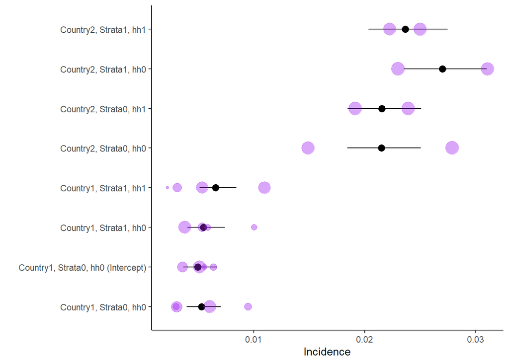

### Example of counterfactual.

We must use a **multivariate normal** distribution. To get this, we should find the variance-covariance matrix from the model and simulate. There is a lot of background information that this simple explanation elides but here is an example.

```r
set.seed(8)
library(MASS)

mean_vals <- coef(mod3)
varcov <- vcov(mod3)

# Simulate 1000 draws from the distribution
draws <- mvrnorm(1000, mean_vals, varcov)

# What is this object? It is 1000 rows and 8 cols
dim(draws)
```

```
## [1] 1000    8
```

```r
# Each column is a coefficient from the model (named in object)
# while each row is a conditional realization of the coefficient
# (depends on itself and other variables in the model)
coef(mod3)[1]
```

```
## (Intercept)
##   -6.783876
```

```r
mean(draws[,1])
```

```
## [1] -6.78586
```

```r
# What do we do with this?
# Let's say we want to know if the effect of the intervention is statistically significant in South Africa (country = 2) and in the high risk strata (strata = 1)
# Create our values. Make sure they are ordered the same as the draws
colnames(draws)
```

```
## [1] "(Intercept)"           "country"               "strata_tst"
## [4] "hh"                    "country:strata_tst"    "country:hh"
## [7] "strata_tst:hh"         "country:strata_tst:hh"
```

```r
my_counterfactual <- data.table(intercept = 1,
                                country = c(1, 1),
                                strata = c(1, 1),
                                hh = c(0, 1),
                                country_strata = 1,
                                country_hh = c(0, 1),
                                strata_hh = c(0, 1),
                                country_strata_hh = c(0, 1))
my_counterfactual
```

```
##    intercept country strata hh country_strata country_hh strata_hh
## 1:         1       1      1  0              1          0         0
## 2:         1       1      1  1              1          1         1
##    country_strata_hh
## 1:                 0
## 2:                 1
```

```r
intervention <- data.table()
control <- data.table()

for(i in 1:1000){
  control <- rbind(control,
                   draws[i,] * my_counterfactual[1,])
  intervention <- rbind(intervention,
                        draws[i,] * my_counterfactual[2,])

}

# Now we can sum up terms to get the predicted value by draw
pred_control <- rowSums(control)
pred_intervention <- rowSums(intervention)

# Find the difference
pred_difference <- pred_control - pred_intervention

# Does the 95% CI cross 0?
mean_diff <- mean(pred_difference)
lower_diff <- quantile(pred_difference, 0.025)
upper_diff <- quantile(pred_difference, 0.975)
```

**The effect of the household intervention on TB prevalence in South Africa among people in the high-risk stratum is not statistically significant (-0.17, 95% CI -0.55 to 0.22)**